# Process plate counts to get fraction infectivities and fit curves

```python
######## snakemake preamble end #########
```

# Process plate counts to get fraction infectivities and fit curves

This notebook is designed to be run using `snakemake`, and analyzes a plate of sequencing-based neutralization assays.

The plots generated by this notebook are interactive, so you can mouseover points for details, use the mouse-scroll to zoom and pan, and use interactive dropdowns at the bottom of the plots.

## Setup

Import Python modules:

```python
import pickle
import sys
import warnings

import altair as alt

import matplotlib.pyplot as plt
import matplotlib.style

import neutcurve
from neutcurve.colorschemes import CBPALETTE, CBMARKERS

import numpy

import pandas as pd

import ruamel.yaml as yaml

_ = alt.data_transformers.disable_max_rows()

# avoid clutter w RuntimeWarning during curve fitting
warnings.filterwarnings("ignore", category=RuntimeWarning)

# faster plotting of neut curves
matplotlib.style.use("fast")
```

Get the variables passed by `snakemake`:

```python
count_csvs = snakemake.input.count_csvs
fate_csvs = snakemake.input.fate_csvs
notebook_funcs = snakemake.input.notebook_funcs
qc_drops_yaml = snakemake.output.qc_drops
frac_infectivity_csv = snakemake.output.frac_infectivity_csv
fits_csv = snakemake.output.fits_csv
fits_pickle = snakemake.output.fits_pickle
viral_barcodes = snakemake.params.viral_barcodes
neut_standard_barcodes = snakemake.params.neut_standard_barcodes
samples = snakemake.params.samples
plate = snakemake.wildcards.plate
plate_params = snakemake.params.plate_params
curve_display_method = snakemake.params.curve_display_method

# get thresholds turning lists into tuples as needed
manual_drops = {
    filter_type: [tuple(w) if isinstance(w, list) else w for w in filter_drops]
    for (filter_type, filter_drops) in plate_params["manual_drops"].items()
}
group = plate_params["group"]
qc_thresholds = plate_params["qc_thresholds"]
curvefit_params = plate_params["curvefit_params"]
curvefit_qc = plate_params["curvefit_qc"]
curvefit_qc["barcode_serum_replicates_ignore_curvefit_qc"] = [
    tuple(w) for w in curvefit_qc["barcode_serum_replicates_ignore_curvefit_qc"]
]

print(f"Processing {plate=}")

samples_df = pd.DataFrame(plate_params["samples"])
print(f"\nPlate has {len(samples)} samples (wells)")
assert all(
    (len(samples_df) == samples_df[c].nunique())
    for c in ["well", "sample", "sample_noplate"]
)
assert len(samples_df) == len(
    samples_df.groupby(["serum_replicate", "dilution_factor"])
)
assert len(samples) == len(count_csvs) == len(fate_csvs) == len(samples_df)

for d, key, title in [
    (manual_drops, "manual_drops", "Data manually specified to drop:"),
    (qc_thresholds, "qc_thresholds", "QC thresholds applied to data:"),
    (curvefit_params, "curvefit_params", "Curve-fitting parameters:"),
    (curvefit_qc, "curvefit_qc", "Curve-fitting QC:"),
]:
    print(f"\n{title}")
    yaml.YAML(typ="rt").dump({key: d}, stream=sys.stdout)
```

```
Processing plate='H3N2_plate'

Plate has 16 samples (wells)

Data manually specified to drop:
manual_drops: {}
```

```
QC thresholds applied to data:
qc_thresholds:
  avg_barcode_counts_per_well: 250
  min_neut_standard_frac_per_well: 0.005
  no_serum_per_viral_barcode_filters:
    min_frac: 0.0005
    max_fold_change: 3
    max_wells: 2
  per_neut_standard_barcode_filters:
    min_frac: 0.005
    max_fold_change: 3
    max_wells: 2
  min_neut_standard_count_per_well: 500
  min_no_serum_count_per_viral_barcode_well: 30
  max_frac_infectivity_per_viral_barcode_well: 5
  min_dilutions_per_barcode_serum_replicate: 6
```

```
Curve-fitting parameters:
curvefit_params:
  frac_infectivity_ceiling: 1
  fixtop:
  - 0.75
  - 1
  fixbottom: 0
  fixslope:
  - 0.8
  - 10
```

```
Curve-fitting QC:
curvefit_qc:
  max_frac_infectivity_at_least: 0
  goodness_of_fit:
    min_R2: 0.7
    max_RMSD: 0.1
  serum_replicates_ignore_curvefit_qc: []
  barcode_serum_replicates_ignore_curvefit_qc: []
```

Load the notebook functions:

```python
print(f"Loading {notebook_funcs=}")
%run {notebook_funcs}
```

```
Loading notebook_funcs='/home/jbloom/.cache/snakemake/snakemake/source-cache/runtime-cache/tmp7kdzbe5y/file/fh/fast/bloom_j/computational_notebooks/jbloom/2025/flu-seqneut-2025/seqneut-pipeline/notebook_funcs.py'
```

Set up dictionary to keep track of wells, barcodes, well-barcodes, and serum-replicates that are dropped:

```python
qc_drops = {
    "wells": {},
    "barcodes": {},
    "barcode_wells": {},
    "barcode_serum_replicates": {},
    "serum_replicates": {},
}

assert set(manual_drops).issubset(
    qc_drops
), f"{manual_drops.keys()=}, {qc_drops.keys()}"
```

## Statistics on barcode-parsing for each sample

Make interactive chart of the "fates" of the sequencing reads parsed for each sample on the plate.

If most sequencing reads are not "valid barcodes", this could potentially indicate some problem in the sequencing or barcode set you are parsing.

Potential fates are:

- *valid barcode*: barcode that matches a known virus or neutralization standard, we hope most reads are this.
- *invalid barcode*: a barcode with proper flanking sequences, but does not match a known virus or neutralization standard. If you have a lot of reads of this type, it is probably a good idea to look at the invalid barcode CSVs (in the `./results/barcode_invalid/` subdirectory created by the pipeline) to see what these invalid barcodes are.
- *unparseable barcode*: could not parse a barcode from this read as there was not a sequence of the correct length with the appropriate flanking sequence.
- *invalid outer flank*: if using an outer upstream or downstream region (`upstream2` or `downstream2` for the [illuminabarcodeparser](https://jbloomlab.github.io/dms_variants/dms_variants.illuminabarcodeparser.html)), reads that are otherwise valid except for this outer flank. Typically you would be using `upstream2` if you have a plate index embedded in your primer, and reads with this classification correspond to a different index than the one for this plate.
- *low quality barcode*: low-quality or `N` nucleotides in barcode, could indicate problem with sequencing.
- *failed chastity filter*: reads that failed the Illumina chastity filter, if these are reported in the FASTQ (they may not be).

Also, if the number of reads per sample is very uneven, that could indicate that you did not do a good job of balancing the different samples in the Illumina sequencing.

```python
fates = (
    pd.concat([pd.read_csv(f).assign(sample=s) for f, s in zip(fate_csvs, samples)])
    .merge(samples_df, validate="many_to_one", on="sample")
    .assign(
        fate_counts=lambda x: x.groupby("fate")["count"].transform("sum"),
        sample_well=lambda x: x["sample_noplate"] + " (" + x["well"] + ")",
    )
    .query("fate_counts > 0")[  # only keep fates with at least one count
        ["fate", "count", "well", "serum_replicate", "sample_well", "dilution_factor"]
    ]
)

assert len(fates) == len(fates.drop_duplicates())

serum_replicates = sorted(fates["serum_replicate"].unique())
sample_wells = list(
    fates.sort_values(["serum_replicate", "dilution_factor"])["sample_well"]
)


serum_selection = alt.selection_point(
    fields=["serum_replicate"],
    bind=alt.binding_select(
        options=[None] + serum_replicates,
        labels=["all"] + serum_replicates,
        name="serum",
    ),
)

fates_chart = (
    alt.Chart(fates)
    .add_params(serum_selection)
    .transform_filter(serum_selection)
    .encode(
        alt.X("count", scale=alt.Scale(nice=False, padding=3)),
        alt.Y(
            "sample_well",
            title=None,
            sort=sample_wells,
        ),
        alt.Color("fate", sort=sorted(fates["fate"].unique(), reverse=True)),
        alt.Order("fate", sort="descending"),
        tooltip=fates.columns.tolist(),
    )
    .mark_bar(height={"band": 0.85})
    .properties(
        height=alt.Step(10),
        width=200,
        title=f"Barcode parsing for {plate}",
    )
    .configure_axis(grid=False)
)

fates_chart
```

[interactive chart not shown]

## Read barcode counts and apply manually specified drops

Read the counts per barcode:

```python
# get barcode counts
counts = (
    pd.concat([pd.read_csv(c).assign(sample=s) for c, s in zip(count_csvs, samples)])
    .merge(samples_df, validate="many_to_one", on="sample")
    .drop(columns=["replicate", "plate", "fastq"])
    .assign(sample_well=lambda x: x["sample_noplate"] + " (" + x["well"] + ")")
)

# classify barcodes as viral or neut standard
barcode_class = pd.concat(
    [
        pd.DataFrame(viral_barcodes).assign(neut_standard=False),
        pd.DataFrame(neut_standard_barcodes).assign(neut_standard=True, strain=pd.NA),
    ],
    ignore_index=True,
)

# merge counts and classification of barcodes
assert set(counts["barcode"]) == set(barcode_class["barcode"])
counts = counts.merge(barcode_class, on="barcode", validate="many_to_one")
assert set(sample_wells) == set(counts["sample_well"])
assert set(serum_replicates) == set(counts["serum_replicate"])
```

Apply any manually specified data drops:

```python
for filter_type, filter_drops in manual_drops.items():
    print(f"\nDropping {len(filter_drops)} {filter_type} specified in manual_drops")
    assert filter_type in qc_drops
    qc_drops[filter_type].update(
        {w: "manual_drop" for w in filter_drops if not isinstance(w, list)}
    )
    if filter_type == "barcode_wells":
        counts = counts[
            ~counts.assign(
                barcode_well=lambda x: x.apply(
                    lambda r: (r["barcode"], r["well"]), axis=1
                )
            )["barcode_well"].isin(qc_drops[filter_type])
        ]
    elif filter_type == "barcode_serum_replicates":
        counts = counts[
            ~counts.assign(
                barcode_serum_replicate=lambda x: x.apply(
                    lambda r: (r["barcode"], r["serum_replicate"]), axis=1
                )
            )["barcode_serum_replicate"].isin(qc_drops[filter_type])
        ]
    elif filter_type == "wells":
        counts = counts[~counts["well"].isin(qc_drops[filter_type])]
    elif filter_type == "barcodes":
        counts = counts[~counts["barcode"].isin(qc_drops[filter_type])]
    elif filter_type == "serum_replicates":
        counts = counts[~counts["serum_replicate"].isin(qc_drops[filter_type])]
    elif filter_type == "barcode_serum_replicates":
        counts = counts[~counts["barcode_serum_replicate"].isin(qc_drops[filter_type])]
    else:
        assert filter_type in set(counts.columns)
        counts = counts[~counts[filter_type].isin(qc_drops[filter_type])]
```

## Average counts per barcode in each well

Plot average counts per barcode. If a sample has inadequate barcode counts, it may not have good enough statistics for accurate analysis, and a QC-threshold is applied:

```python
avg_barcode_counts = (
    counts.groupby(
        ["well", "serum_replicate", "sample_well"],
        dropna=False,
        as_index=False,
    )
    .aggregate(avg_count=pd.NamedAgg("count", "mean"))
    .assign(
        fails_qc=lambda x: (
            x["avg_count"] < qc_thresholds["avg_barcode_counts_per_well"]
        ),
    )
)

avg_barcode_counts_chart = (
    alt.Chart(avg_barcode_counts)
    .add_params(serum_selection)
    .transform_filter(serum_selection)
    .encode(
        alt.X(
            "avg_count",
            title="average barcode counts per well",
            scale=alt.Scale(nice=False, padding=3),
        ),
        alt.Y("sample_well", sort=sample_wells),
        alt.Color(
            "fails_qc",
            title=f"fails {qc_thresholds['avg_barcode_counts_per_well']=}",
            legend=alt.Legend(titleLimit=500),
        ),
        tooltip=[
            alt.Tooltip(c, format=".3g") if avg_barcode_counts[c].dtype == float else c
            for c in avg_barcode_counts.columns
        ],
    )
    .mark_bar(height={"band": 0.85})
    .properties(
        height=alt.Step(10),
        width=250,
        title=f"Average barcode counts per well for {plate}",
    )
    .configure_axis(grid=False)
)

display(avg_barcode_counts_chart)

# drop wells failing QC
avg_barcode_counts_per_well_drops = list(avg_barcode_counts.query("fails_qc")["well"])
print(
    f"\nDropping {len(avg_barcode_counts_per_well_drops)} wells for failing "
    f"{qc_thresholds['avg_barcode_counts_per_well']=}: "
    + str(avg_barcode_counts_per_well_drops)
)
qc_drops["wells"].update(
    {w: "avg_barcode_counts_per_well" for w in avg_barcode_counts_per_well_drops}
)
counts = counts[~counts["well"].isin(qc_drops["wells"])]
```

[interactive chart not shown]

```
Dropping 0 wells for failing qc_thresholds['avg_barcode_counts_per_well']=250: []
```

## Fraction of counts from neutralization standard

Determine the fraction of counts from the neutralization standard in each sample, and make sure this fraction passess the QC threshold.

```python
neut_standard_fracs = (
    counts.assign(
        neut_standard_count=lambda x: x["count"] * x["neut_standard"].astype(int)
    )
    .groupby(
        ["well", "serum_replicate", "sample_well"],
        dropna=False,
        as_index=False,
    )
    .aggregate(
        total_count=pd.NamedAgg("count", "sum"),
        neut_standard_count=pd.NamedAgg("neut_standard_count", "sum"),
    )
    .assign(
        neut_standard_frac=lambda x: x["neut_standard_count"] / x["total_count"],
        fails_qc=lambda x: (
            x["neut_standard_frac"] < qc_thresholds["min_neut_standard_frac_per_well"]
        ),
    )
)

neut_standard_fracs_chart = (
    alt.Chart(neut_standard_fracs)
    .add_params(serum_selection)
    .transform_filter(serum_selection)
    .encode(
        alt.X(
            "neut_standard_frac",
            title="frac counts from neutralization standard per well",
            scale=alt.Scale(nice=False, padding=3),
        ),
        alt.Y("sample_well", sort=sample_wells),
        alt.Color(
            "fails_qc",
            title=f"fails {qc_thresholds['min_neut_standard_frac_per_well']=}",
            legend=alt.Legend(titleLimit=500),
        ),
        tooltip=[
            alt.Tooltip(c, format=".3g") if neut_standard_fracs[c].dtype == float else c
            for c in neut_standard_fracs.columns
        ],
    )
    .mark_bar(height={"band": 0.85})
    .properties(
        height=alt.Step(10),
        width=250,
        title=f"Neutralization-standard fracs per well for {plate}",
    )
    .configure_axis(grid=False)
    .configure_legend(titleLimit=1000)
)

display(neut_standard_fracs_chart)
```

[interactive chart not shown]

```python
# drop wells failing QC
min_neut_standard_frac_per_well_drops = list(
    neut_standard_fracs.query("fails_qc")["well"]
)
print(
    f"\nDropping {len(min_neut_standard_frac_per_well_drops)} wells for failing "
    f"{qc_thresholds['min_neut_standard_frac_per_well']=}: "
    + str(min_neut_standard_frac_per_well_drops)
)
qc_drops["wells"].update(
    {
        w: "min_neut_standard_frac_per_well"
        for w in min_neut_standard_frac_per_well_drops
    }
)
counts = counts[~counts["well"].isin(qc_drops["wells"])]
```

```
Dropping 0 wells for failing qc_thresholds['min_neut_standard_frac_per_well']=0.005: []
```

## Consistency and minimum fractions for barcodes

We examine the fraction of counts attributable to each barcode. We do this splitting the data two ways:

1. Looking at all viral (but not neut-standard) barcodes only for the no-serum samples (wells).
2. Looking at just the neut-standard barcodes for all samples (wells).

We plot these fractions in interactive plots (you can mouseover points and zoom) so you can identify barcodes that fail the expected consistency QC thresholds.

We also make sure the barcodes meet specified QC minimum thresholds for all samples, and flag any that do not.

```python
barcode_selection = alt.selection_point(fields=["barcode"], on="mouseover", empty=False)

# look at all samples for neut standard barcodes, or no-serum samples for all barcodes
for is_neut_standard, df in counts.groupby("neut_standard"):
    if is_neut_standard:
        print(
            f"\n\n{'=' * 89}\nAnalyzing neut-standard barcodes from all samples (wells)"
        )
        qc_name = "per_neut_standard_barcode_filters"
    else:
        print(f"\n\n{'=' * 89}\nAnalyzing all barcodes from no-serum samples (wells)")
        qc_name = "no_serum_per_viral_barcode_filters"
        df = df.query("serum == 'none'")

    df = df.assign(
        sample_counts=lambda x: x.groupby("sample")["count"].transform("sum"),
        count_frac=lambda x: x["count"] / x["sample_counts"],
        median_count_frac=lambda x: x.groupby("barcode")["count_frac"].transform(
            "median"
        ),
        fold_change_from_median=lambda x: numpy.where(
            x["count_frac"] > x["median_count_frac"],
            x["count_frac"] / x["median_count_frac"],
            x["median_count_frac"] / x["count_frac"],
        ),
    )[
        [
            "barcode",
            "count",
            "sample_well",
            "count_frac",
            "fold_change_from_median",
        ]
        + ([] if is_neut_standard else ["strain"])
    ]

    # barcode fails QC if fails in sufficient wells
    qc = qc_thresholds[qc_name]
    print(f"Apply QC {qc_name}: {qc}\n")
    fails_qc = (
        df.assign(
            fails_qc=lambda x: ~(
                (x["count_frac"] >= qc["min_frac"])
                & (x["fold_change_from_median"] <= qc["max_fold_change"])
            ),
        )
        .groupby("barcode", as_index=False)
        .aggregate(n_wells_fail_qc=pd.NamedAgg("fails_qc", "sum"))
        .assign(fails_qc=lambda x: x["n_wells_fail_qc"] >= qc["max_wells"])[
            ["barcode", "fails_qc"]
        ]
    )
    df = df.merge(fails_qc, on="barcode", validate="many_to_one")

    # make chart
    evenness_chart = (
        alt.Chart(df)
        .add_params(barcode_selection)
        .encode(
            alt.X(
                "count_frac",
                title=(
                    "barcode's fraction of neut standard counts"
                    if is_neut_standard
                    else "barcode's fraction of non-neut standard counts"
                ),
                scale=alt.Scale(nice=False, padding=5),
            ),
            alt.Y("sample_well", sort=sample_wells),
            alt.Fill(
                "fails_qc",
                title=f"fails {qc_name}",
                legend=alt.Legend(titleLimit=500),
            ),
            strokeWidth=alt.condition(barcode_selection, alt.value(2), alt.value(0)),
            size=alt.condition(barcode_selection, alt.value(60), alt.value(35)),
            tooltip=[
                alt.Tooltip(c, format=".2g") if df[c].dtype == float else c
                for c in df.columns
            ],
        )
        .mark_circle(fillOpacity=0.45, stroke="black", strokeOpacity=1)
        .properties(
            height=alt.Step(10),
            width=300,
            title=alt.TitleParams(
                (
                    f"{plate} all samples, neut-standard barcodes"
                    if is_neut_standard
                    else f"{plate} no-serum samples, all barcodes"
                ),
                subtitle="x-axis is zoomable (use mouse scroll/pan)",
            ),
        )
        .configure_axis(grid=False)
        .configure_legend(titleLimit=1000)
        .interactive()
    )

    display(evenness_chart)

    # drop barcodes failing QC
    barcode_drops = list(fails_qc.query("fails_qc")["barcode"])
    print(
        f"\nDropping {len(barcode_drops)} barcodes for failing {qc=}: {barcode_drops}"
    )
    qc_drops["barcodes"].update(
        {bc: "min_neut_standard_frac_per_well" for bc in barcode_drops}
    )
    counts = counts[~counts["barcode"].isin(qc_drops["barcodes"])]
```

```
=========================================================================================
Analyzing all barcodes from no-serum samples (wells)
Apply QC no_serum_per_viral_barcode_filters: {'min_frac': 0.0005, 'max_fold_change': 3, 'max_wells': 2}
```

[interactive chart not shown]

[output not shown]

[interactive chart not shown]

```
Dropping 0 barcodes for failing qc={'min_frac': 0.005, 'max_fold_change': 3, 'max_wells': 2}: []
```

## Compute fraction infectivity

The fraction infectivity for viral barcode $v_b$ in sample $s$ is computed as: $$ F_{v_b,s} = \frac{c_{v_b,s} / \left(\sum_{n_b} c_{n_b,s}\right)}{{\rm median}_{s_0}\left[ c_{v_b,s_0} / \left(\sum_{n_b} c_{n_b,s_0}\right)\right]} $$ where

- $c_{v_b,s}$ is the counts of viral barcode $v_b$ in sample $s$.
- $\sum_{n_b} c_{n_b,s}$ is the sum of the counts for all neutralization standard barcodes $n_b$ for sample $s$.
- $c_{v_b,s_0}$ is the counts of viral barcode $v_b$ in no-serum sample $s_0$.
- $\sum_{n_b} c_{n_b,s_0}$ is the sum of the counts for all neutralization standard barcodes $n_b$ for no-serum sample $s_0$.
- ${\rm median}_{s_0}\left[ c_{v_b,s_0} / \left(\sum_{n_b} c_{n_b,s_0}\right)\right]$ is the median taken across all no-serum samples of the counts of viral barcode $v_b$ versus the total counts for all neutralization standard barcodes.

First, compute the total neutralization-standard counts for each sample (well). Plot these, and drop any wells that do not meet the QC threshold.

```python
neut_standard_counts = (
    counts.query("neut_standard")
    .groupby(
        ["well", "serum_replicate", "sample_well", "dilution_factor"],
        dropna=False,
        as_index=False,
    )
    .aggregate(neut_standard_count=pd.NamedAgg("count", "sum"))
    .assign(
        fails_qc=lambda x: (
            x["neut_standard_count"] < qc_thresholds["min_neut_standard_count_per_well"]
        ),
    )
)

neut_standard_counts_chart = (
    alt.Chart(neut_standard_counts)
    .add_params(serum_selection)
    .transform_filter(serum_selection)
    .encode(
        alt.X(
            "neut_standard_count",
            title="counts from neutralization standard",
            scale=alt.Scale(nice=False, padding=3),
        ),
        alt.Y("sample_well", sort=sample_wells),
        alt.Color(
            "fails_qc",
            title=f"fails {qc_thresholds['min_neut_standard_count_per_well']=}",
            legend=alt.Legend(titleLimit=500),
        ),
        tooltip=[
            (
                alt.Tooltip(c, format=".3g")
                if neut_standard_counts[c].dtype == float
                else c
            )
            for c in neut_standard_counts.columns
        ],
    )
    .mark_bar(height={"band": 0.85})
    .properties(
        height=alt.Step(10),
        width=250,
        title=f"Neutralization-standard counts for {plate}",
    )
    .configure_axis(grid=False)
    .configure_legend(titleLimit=1000)
)

display(neut_standard_counts_chart)
```

[interactive chart not shown]

```python
# drop wells failing QC
min_neut_standard_count_per_well_drops = list(
    neut_standard_counts.query("fails_qc")["well"]
)
print(
    f"\nDropping {len(min_neut_standard_count_per_well_drops)} wells for failing "
    f"{qc_thresholds['min_neut_standard_count_per_well']=}: "
    + str(min_neut_standard_count_per_well_drops)
)
qc_drops["wells"].update(
    {
        w: "min_neut_standard_count_per_well"
        for w in min_neut_standard_count_per_well_drops
    }
)
neut_standard_counts = neut_standard_counts[
    ~neut_standard_counts["well"].isin(qc_drops["wells"])
]
counts = counts[~counts["well"].isin(qc_drops["wells"])]
```

```
Dropping 0 wells for failing qc_thresholds['min_neut_standard_count_per_well']=500: []
```

Compute and plot the no-serum sample viral barcode counts and check if they pass the QC filters.

```python
no_serum_counts = (
    counts.query("serum == 'none'")
    .query("not neut_standard")
    .merge(neut_standard_counts, validate="many_to_one")[
        ["barcode", "strain", "well", "sample_well", "count", "neut_standard_count"]
    ]
    .assign(
        fails_qc=lambda x: (
            x["count"] <= qc_thresholds["min_no_serum_count_per_viral_barcode_well"]
        ),
    )
)

strains = sorted(no_serum_counts["strain"].unique())
strain_selection_dropdown = alt.selection_point(
    fields=["strain"],
    bind=alt.binding_select(
        options=[None] + strains,
        labels=["all"] + strains,
        name="virus strain",
    ),
)

# make chart
no_serum_counts_plot_df = no_serum_counts.drop(columns=["well", "neut_standard_count"])
no_serum_counts_chart = (
    alt.Chart(no_serum_counts_plot_df)
    .add_params(barcode_selection, strain_selection_dropdown)
    .transform_filter(strain_selection_dropdown)
    .encode(
        alt.X(
            "count", title="viral barcode count", scale=alt.Scale(nice=False, padding=5)
        ),
        alt.Y("sample_well", sort=sample_wells),
        alt.Fill(
            "fails_qc",
            title=f"fails {qc_thresholds['min_no_serum_count_per_viral_barcode_well']=}",
            legend=alt.Legend(titleLimit=500),
        ),
        strokeWidth=alt.condition(barcode_selection, alt.value(2), alt.value(0)),
        size=alt.condition(barcode_selection, alt.value(60), alt.value(35)),
        tooltip=no_serum_counts_plot_df.columns.tolist(),
    )
    .mark_circle(fillOpacity=0.6, stroke="black", strokeOpacity=1)
    .properties(
        height=alt.Step(10),
        width=400,
        title=f"{plate} viral barcode counts in no-serum samples",
    )
    .configure_axis(grid=False)
    .configure_legend(titleLimit=1000)
    .interactive()
)

display(no_serum_counts_chart)
```

[interactive chart not shown]

```python
# drop barcode / wells failing QC
min_no_serum_count_per_viral_barcode_well_drops = list(
    no_serum_counts.query("fails_qc")[["barcode", "well"]].itertuples(
        index=False, name=None
    )
)
print(
    f"\nDropping {len(min_no_serum_count_per_viral_barcode_well_drops)} barcode-wells for failing "
    f"{qc_thresholds['min_no_serum_count_per_viral_barcode_well']=}: "
    + str(min_no_serum_count_per_viral_barcode_well_drops)
)
qc_drops["barcode_wells"].update(
    {
        w: "min_no_serum_count_per_viral_barcode_well"
        for w in min_no_serum_count_per_viral_barcode_well_drops
    }
)
no_serum_counts = no_serum_counts[
    ~no_serum_counts.assign(
        barcode_well=lambda x: x.apply(lambda r: (r["barcode"], r["well"]), axis=1)
    )["barcode_well"].isin(qc_drops["barcode_wells"])
]
counts = counts[
    ~counts.assign(
        barcode_well=lambda x: x.apply(lambda r: (r["barcode"], r["well"]), axis=1)
    )["barcode_well"].isin(qc_drops["barcode_wells"])
]
```

```
Dropping 4 barcode-wells for failing qc_thresholds['min_no_serum_count_per_viral_barcode_well']=30: [('CCTATAAGGCCTTACG', 'A10'), ('GATTCACGGCCCACAA', 'B10'), ('CACCGACCAACTCTCT', 'E10'), ('GACCAAAGCTGCAGGG', 'E10')]
```

Compute and plot the median ratio of viral barcode count to neut standard counts across no-serum samples. If library composition is equal, all of these values should be similar:

```python
median_no_serum_ratio = (
    no_serum_counts.assign(ratio=lambda x: x["count"] / x["neut_standard_count"])
    .groupby(["barcode", "strain"], as_index=False)
    .aggregate(median_no_serum_ratio=pd.NamedAgg("ratio", "median"))
)

strain_selection = alt.selection_point(fields=["strain"], on="mouseover", empty=False)

median_no_serum_ratio_chart = (
    alt.Chart(median_no_serum_ratio)
    .add_params(strain_selection)
    .encode(
        alt.X(
            "median_no_serum_ratio",
            title="median ratio of counts",
            scale=alt.Scale(nice=False, padding=5),
        ),
        alt.Y(
            "barcode",
            sort=alt.SortField("median_no_serum_ratio", order="descending"),
            axis=alt.Axis(labelFontSize=5),
        ),
        color=alt.condition(strain_selection, alt.value("orange"), alt.value("gray")),
        tooltip=[
            (
                alt.Tooltip(c, format=".3g")
                if median_no_serum_ratio[c].dtype == float
                else c
            )
            for c in median_no_serum_ratio.columns
        ],
    )
    .mark_bar(height={"band": 0.85})
    .properties(
        height=alt.Step(5),
        width=250,
        title=f"{plate} no-serum median ratio viral barcode to neut-standard barcode",
    )
    .configure_axis(grid=False)
    .configure_legend(titleLimit=1000)
)

display(median_no_serum_ratio_chart)
```

[interactive chart not shown]

Compute the actual fraction infectivities. We compute both the raw fraction infectivities and the ones with the ceiling applied:

```python
frac_infectivity = (
    counts.query("not neut_standard")
    .query("serum != 'none'")
    .merge(median_no_serum_ratio, validate="many_to_one")
    .merge(neut_standard_counts, validate="many_to_one")
    .assign(
        frac_infectivity_raw=lambda x: (
            (x["count"] / x["neut_standard_count"]) / x["median_no_serum_ratio"]
        ),
        frac_infectivity_ceiling=lambda x: x["frac_infectivity_raw"].clip(
            upper=curvefit_params["frac_infectivity_ceiling"]
        ),
        concentration=lambda x: 1 / x["dilution_factor"],
        plate_barcode=lambda x: x["plate_replicate"] + "-" + x["barcode"],
    )[
        [
            "barcode",
            "plate_barcode",
            "well",
            "strain",
            "serum",
            "serum_replicate",
            "dilution_factor",
            "concentration",
            "frac_infectivity_raw",
            "frac_infectivity_ceiling",
        ]
    ]
)

assert len(
    frac_infectivity.groupby(["serum", "plate_barcode", "dilution_factor"])
) == len(frac_infectivity)
assert frac_infectivity["dilution_factor"].notnull().all()
assert frac_infectivity["frac_infectivity_raw"].notnull().all()
assert frac_infectivity["frac_infectivity_ceiling"].notnull().all()
```

Plot the fraction infectivities, both the raw values and with the ceiling applied:

```python
frac_infectivity_cols = {
    "frac_infectivity_raw": "raw fraction infectivity",
    "frac_infectivity_ceiling": f"fraction infectivity with ceiling at {curvefit_params['frac_infectivity_ceiling']}",
}

frac_infectivity_chart_df = frac_infectivity.assign(
    fails_qc=lambda x: (
        x["frac_infectivity_raw"]
        > qc_thresholds["max_frac_infectivity_per_viral_barcode_well"]
    ),
)[
    [
        "barcode",
        "strain",
        "well",
        "serum_replicate",
        "dilution_factor",
        "fails_qc",
        *list(frac_infectivity_cols),
    ]
].rename(
    columns=frac_infectivity_cols
)

# some manipulations to shrink data frame plotted by altair below by putting
# them in smaller data frames that are used via transform_lookup
barcode_lookup_df = frac_infectivity[["barcode", "strain"]].drop_duplicates()
assert len(barcode_lookup_df) == barcode_lookup_df["barcode"].nunique()
well_lookup_df = frac_infectivity[
    ["well", "serum_replicate", "dilution_factor"]
].drop_duplicates()
assert len(well_lookup_df) == well_lookup_df["well"].nunique()

frac_infectivity_chart_df = frac_infectivity_chart_df.drop(
    columns=["strain", "serum_replicate", "dilution_factor"]
)
```

```python
frac_infectivity_chart = (
    alt.Chart(frac_infectivity_chart_df)
    .transform_lookup(
        lookup="barcode",
        from_=alt.LookupData(barcode_lookup_df, key="barcode", fields=["strain"]),
    )
    .transform_lookup(
        lookup="well",
        from_=alt.LookupData(
            well_lookup_df, key="well", fields=["serum_replicate", "dilution_factor"]
        ),
    )
    .transform_fold(
        frac_infectivity_cols.values(), ["ceiling_applied", "frac_infectivity"]
    )
    .add_params(strain_selection_dropdown, barcode_selection)
    .transform_filter(strain_selection_dropdown)
    .encode(
        alt.X(
            "dilution_factor:Q",
            title="dilution factor",
            scale=alt.Scale(nice=False, padding=5, type="log"),
        ),
        alt.Y(
            "frac_infectivity:Q",
            title="fraction infectivity",
            scale=alt.Scale(nice=False, padding=5),
        ),
        alt.Column(
            "ceiling_applied:N",
            sort="descending",
            title=None,
            header=alt.Header(labelFontSize=13, labelFontStyle="bold", labelPadding=2),
        ),
        alt.Row(
            "serum_replicate:N",
            title=None,
            spacing=3,
            header=alt.Header(labelFontSize=13, labelFontStyle="bold"),
        ),
        alt.Detail("barcode"),
        alt.Shape(
            "fails_qc",
            title=f"fails {qc_thresholds['max_frac_infectivity_per_viral_barcode_well']=}",
            legend=alt.Legend(titleLimit=500, orient="bottom"),
        ),
        color=alt.condition(
            barcode_selection, alt.value("black"), alt.value("MediumBlue")
        ),
        strokeWidth=alt.condition(barcode_selection, alt.value(3), alt.value(1)),
        opacity=alt.condition(barcode_selection, alt.value(1), alt.value(0.25)),
        tooltip=[
            (
                alt.Tooltip(c, format=".3g")
                if frac_infectivity_chart_df[c].dtype == float
                else c
            )
            for c in frac_infectivity_chart_df.columns
        ]
        + [
            alt.Tooltip("strain:N"),
            alt.Tooltip("serum_replicate:N"),
            alt.Tooltip("dilution_factor:Q"),
        ],
    )
    .mark_line(point=True)
    .properties(
        height=150,
        width=250,
        title=f"Fraction infectivities for {plate}",
    )
    .interactive(bind_x=False)
    .configure_axis(grid=False)
    .configure_legend(titleLimit=1000)
    .configure_point(size=50)
    .resolve_scale(x="independent", y="independent")
)

display(frac_infectivity_chart)
```

[interactive chart not shown]

```python
# drop barcode / wells failing QC
max_frac_infectivity_per_viral_barcode_well_drops = list(
    frac_infectivity_chart_df.query("fails_qc")[["barcode", "well"]]
    .drop_duplicates()
    .itertuples(index=False, name=None)
)
print(
    f"\nDropping {len(max_frac_infectivity_per_viral_barcode_well_drops)} barcode-wells for failing "
    f"{qc_thresholds['max_frac_infectivity_per_viral_barcode_well']=}: "
    + str(max_frac_infectivity_per_viral_barcode_well_drops)
)
qc_drops["barcode_wells"].update(
    {
        w: "max_frac_infectivity_per_viral_barcode_well"
        for w in max_frac_infectivity_per_viral_barcode_well_drops
    }
)
frac_infectivity = frac_infectivity[
    ~frac_infectivity.assign(
        barcode_well=lambda x: x.apply(lambda r: (r["barcode"], r["well"]), axis=1)
    )["barcode_well"].isin(qc_drops["barcode_wells"])
]
```

```
Dropping 0 barcode-wells for failing qc_thresholds['max_frac_infectivity_per_viral_barcode_well']=5: []
```

Check how many dilutions we have per barcode / serum-replicate:

```python
n_dilutions = (
    frac_infectivity.groupby(["serum_replicate", "strain", "barcode"], as_index=False)
    .aggregate(**{"number of dilutions": pd.NamedAgg("dilution_factor", "nunique")})
    .assign(
        fails_qc=lambda x: (
            x["number of dilutions"]
            < qc_thresholds["min_dilutions_per_barcode_serum_replicate"]
        ),
    )
)

n_dilutions_chart = (
    alt.Chart(n_dilutions)
    .add_params(barcode_selection)
    .encode(
        alt.X("number of dilutions", scale=alt.Scale(nice=False, padding=4)),
        alt.Y("strain", title=None),
        alt.Column(
            "serum_replicate",
            title=None,
            header=alt.Header(labelFontSize=12, labelFontStyle="bold", labelPadding=0),
        ),
        alt.Fill(
            "fails_qc",
            title=f"fails {qc_thresholds['min_dilutions_per_barcode_serum_replicate']=}",
            legend=alt.Legend(titleLimit=500, orient="bottom"),
        ),
        strokeWidth=alt.condition(barcode_selection, alt.value(2), alt.value(0)),
        size=alt.condition(barcode_selection, alt.value(55), alt.value(35)),
        tooltip=[
            alt.Tooltip(c, format=".3g") if n_dilutions[c].dtype == float else c
            for c in n_dilutions.columns
        ],
    )
    .mark_circle(stroke="black", strokeOpacity=1, fillOpacity=0.45)
    .properties(
        height=alt.Step(10),
        width=120,
        title=alt.TitleParams(
            "number of dilutions for each barcode for each serum-replicate", dy=-2
        ),
    )
)

display(n_dilutions_chart)

# drop barcode / serum-replicates failing QC
min_dilutions_per_barcode_serum_replicate_drops = list(
    n_dilutions.query("fails_qc")[["barcode", "serum_replicate"]].itertuples(
        index=False, name=None
    )
)
print(
    f"\nDropping {len(min_dilutions_per_barcode_serum_replicate_drops)} barcode/serum-replicates for failing "
    f"{qc_thresholds['min_dilutions_per_barcode_serum_replicate']=}: "
    + str(min_dilutions_per_barcode_serum_replicate_drops)
)
qc_drops["barcode_serum_replicates"].update(
    {
        w: "min_dilutions_per_barcode_serum_replicate"
        for w in min_dilutions_per_barcode_serum_replicate_drops
    }
)
frac_infectivity = frac_infectivity[
    ~frac_infectivity.assign(
        barcode_serum_replicate=lambda x: x.apply(
            lambda r: (r["barcode"], r["serum_replicate"]), axis=1
        )
    )["barcode_serum_replicate"].isin(qc_drops["barcode_serum_replicates"])
]
```

[interactive chart not shown]

```
Dropping 0 barcode/serum-replicates for failing qc_thresholds['min_dilutions_per_barcode_serum_replicate']=6: []
```

## Fit neutralization curves without applying QC to curves

First fit curves to all serum replicates, then we will apply QC on the curve fits. Note that the fitting is done to the fraction infectivities **with** the ceiling:

```python
fits_noqc = neutcurve.CurveFits(
    frac_infectivity.rename(
        columns={
            "frac_infectivity_ceiling": "fraction infectivity",
            "concentration": "serum concentration",
        }
    ),
    conc_col="serum concentration",
    fracinf_col="fraction infectivity",
    virus_col="strain",
    serum_col="serum_replicate",
    replicate_col="barcode",
    fixtop=curvefit_params["fixtop"],
    fixbottom=curvefit_params["fixbottom"],
    fixslope=curvefit_params["fixslope"],
)
```

Determine which fits fail the curve fitting QC, and plot them. Note the plot indicates as failing QC any barcode / serum-replicate that fails, even if we are also specified to ignore the QC for that one (so it will not be removed later):

```python
goodness_of_fit = curvefit_qc["goodness_of_fit"]

fit_params_noqc = (
    frac_infectivity.groupby(["serum_replicate", "barcode"], as_index=False)
    .aggregate(max_frac_infectivity=pd.NamedAgg("frac_infectivity_ceiling", "max"))
    .merge(
        fits_noqc.fitParams(average_only=False, no_average=True)[
            ["serum", "virus", "replicate", "r2", "rmsd"]
        ].rename(columns={"serum": "serum_replicate", "replicate": "barcode"}),
        validate="one_to_one",
    )
    .assign(
        fails_max_frac_infectivity_at_least=lambda x: (
            x["max_frac_infectivity"] < curvefit_qc["max_frac_infectivity_at_least"]
        ),
        fails_goodness_of_fit=lambda x: (
            (x["r2"] < goodness_of_fit["min_R2"])
            & (x["rmsd"] > goodness_of_fit["max_RMSD"])
        ),
        fails_qc=lambda x: (
            x["fails_max_frac_infectivity_at_least"] | x["fails_goodness_of_fit"]
        ),
        ignore_qc=lambda x: x.apply(
            lambda r: (
                (
                    r["serum_replicate"]
                    in curvefit_qc["serum_replicates_ignore_curvefit_qc"]
                )
                or (
                    (r["barcode"], r["serum_replicate"])
                    in curvefit_qc["barcode_serum_replicates_ignore_curvefit_qc"]
                )
            ),
            axis=1,
        ),
    )
)
```

```python
print(f"Plotting barcode / serum-replicates that fail {curvefit_qc=}\n")

fit_params_noqc_base_chart = alt.Chart(fit_params_noqc).add_params(barcode_selection)
fit_params_noqc_chart = []
for prop, col in [
    ("max frac infectivity", "max_frac_infectivity"),
    ("curve fit R2", "r2"),
    ("curve fit RMSD", "rmsd"),
]:
    fit_params_noqc_chart.append(
        fit_params_noqc_base_chart.encode(
            alt.X(col, title=prop, scale=alt.Scale(nice=False, padding=4)),
            alt.Y("virus", title=None),
            alt.Fill("fails_qc"),
            alt.Column(
                "serum_replicate",
                title=None,
                header=alt.Header(
                    labelFontSize=12, labelFontStyle="bold", labelPadding=0
                ),
            ),
            strokeWidth=alt.condition(barcode_selection, alt.value(2), alt.value(0)),
            size=alt.condition(barcode_selection, alt.value(55), alt.value(35)),
            tooltip=[
                alt.Tooltip(c, format=".3g") if fit_params_noqc[c].dtype == float else c
                for c in fit_params_noqc.columns
            ],
        )
        .mark_circle(stroke="black", strokeOpacity=1, fillOpacity=0.55)
        .properties(
            height=alt.Step(10),
            width=90,
            title=alt.TitleParams(f"{prop} for each barcode serum-replicate", dy=-2),
        )
    )

alt.vconcat(*fit_params_noqc_chart)
```

```
Plotting barcode / serum-replicates that fail curvefit_qc={'max_frac_infectivity_at_least': 0, 'goodness_of_fit': {'min_R2': 0.7, 'max_RMSD': 0.1}, 'serum_replicates_ignore_curvefit_qc': [], 'barcode_serum_replicates_ignore_curvefit_qc': []}
```

[interactive chart not shown]

Now plot curves for all virus vs serum-replicates that have a barcode that fails any of the QC. In these plots, the suffix on the barcode name in the color key indicates if it passed or failed QC:

```
Here are barcode / serum-replicates that fail curvefit_qc={'max_frac_infectivity_at_least': 0, 'goodness_of_fit': {'min_R2': 0.7, 'max_RMSD': 0.1}, 'serum_replicates_ignore_curvefit_qc': [], 'barcode_serum_replicates_ignore_curvefit_qc': []}
```

|  | serum_replicate | barcode | max_frac_infectivity | virus | r2 | rmsd | fails_max_frac_infectivity_at_least | fails_goodness_of_fit | fails_qc | ignore_qc |
| --- | --- | --- | --- | --- | --- | --- | --- | --- | --- | --- |
| 0 | A23038d0_r32_75K | AAAGATAAATTCAAAA | 1.000000 | A/SENDAI/45/2023 | 0.617148 | 0.195367 | False | True | True | False |
| 1 | A23038d0_r32_75K | AAATGCTGAGAGGGTA | 0.862929 | A/South_Africa/R07188/2023 | 0.551583 | 0.186557 | False | True | True | False |
| 2 | A23038d0_r32_75K | AACGACACTTACATCC | 1.000000 | A/Netherlands/01693/2023 | 0.636100 | 0.180683 | False | True | True | False |
| 3 | A23038d0_r32_75K | AATAGGCCCAAATCCA | 1.000000 | A/Oman/3011/2023 | 0.565405 | 0.190553 | False | True | True | False |
| 4 | A23038d0_r32_75K | AATCTTTCCAATCTTG | 1.000000 | A/SouthSudan/642/2023 | 0.502680 | 0.222618 | False | True | True | False |
| 5 | A23038d0_r32_75K | AATTACGCATAGGCCA | 0.892113 | A/Malaysia/IMR-SARI1989/2023 | 0.531560 | 0.203096 | False | True | True | False |
| 6 | A23038d0_r32_75K | ACAAAGATAAAAATTT | 1.000000 | A/Guangdong-Futian/1980/2023 | 0.639012 | 0.184513 | False | True | True | False |
| 7 | A23038d0_r32_75K | AGATCATAAGCAATAA | 1.000000 | A/Catalonia/2041146NS/2023 | 0.585573 | 0.192508 | False | True | True | False |
| 8 | A23038d0_r32_75K | AGGGACTTTATTGTCC | 1.000000 | A/South_Dakota/22/2023 | 0.552145 | 0.236778 | False | True | True | False |
| 9 | A23038d0_r32_75K | AGGTGCGAGCCATCAG | 0.758526 | A/Bangkok/P3599/2023 | 0.429296 | 0.187407 | False | True | True | False |
| 10 | A23038d0_r32_75K | ATCGAAAAAACTGCAA | 0.997784 | A/South_Africa/K056872/2023 | 0.673572 | 0.157786 | False | True | True | False |
| 11 | A23038d0_r32_75K | ATCGATTCGATTGACG | 0.668517 | A/Victoria/1033/2023 | 0.452359 | 0.170759 | False | True | True | False |
| 12 | A23038d0_r32_75K | ATGGTTATCTTACCTT | 1.000000 | A/Luga/RII-11393S/2023 | 0.540049 | 0.243452 | False | True | True | False |
| 13 | A23038d0_r32_75K | ATTAGATTATAACGTA | 1.000000 | A/Cambodia/e0826360/2020 | 0.569252 | 0.234189 | False | True | True | False |
| 14 | A23038d0_r32_75K | CACCGACCAACTCTCT | 0.668522 | A/South_Africa/R06240/2023 | -0.099671 | 0.203397 | False | True | True | False |
| 15 | A23038d0_r32_75K | CACGTTAGTGAGACTT | 0.943296 | A/Romania/543634/2022 | 0.675439 | 0.168308 | False | True | True | False |
| 16 | A23038d0_r32_75K | CATAAAAGACTGTATA | 1.000000 | A/Thailand/8/2022 | 0.613899 | 0.184037 | False | True | True | False |
| 17 | A23038d0_r32_75K | CATAATGCACAAACGC | 0.827674 | A/South_Africa/R06359/2023 | 0.561621 | 0.175688 | False | True | True | False |
| 18 | A23038d0_r32_75K | CCACAAGTTTGAAAAC | 0.951468 | A/Finland/399/2023 | 0.556492 | 0.184352 | False | True | True | False |
| 19 | A23038d0_r32_75K | CCATCACCTTATACAC | 0.927907 | A/Netherlands/01693/2023 | 0.351597 | 0.222657 | False | True | True | False |
| 20 | A23038d0_r32_75K | CCGATAAGACGTCGCT | 0.926675 | A/California/81/2023 | 0.685631 | 0.161735 | False | True | True | False |
| 21 | A23038d0_r32_75K | CCTATAAGGCCTTACG | 1.000000 | A/Wisconsin/27/2023 | 0.311398 | 0.247445 | False | True | True | False |
| 22 | A23038d0_r32_75K | CGCGAACAACAGGGGA | 0.935992 | A/Krabi/THIS050/2023 | 0.661590 | 0.172954 | False | True | True | False |
| 23 | A23038d0_r32_75K | CGTCAGAAGTTTATAA | 1.000000 | A/Luga/RII-11393S/2023 | 0.443012 | 0.261734 | False | True | True | False |
| 24 | A23038d0_r32_75K | CTATCTTAATCTACAG | 1.000000 | A/Darwin/6/2021 | -0.350804 | 0.278777 | False | True | True | False |
| 25 | A23038d0_r32_75K | CTGCGAATATTGTGAC | 1.000000 | A/SENDAI/45/2023 | 0.673053 | 0.203210 | False | True | True | False |
| 26 | A23038d0_r32_75K | CTTGAATACACAAACA | 1.000000 | A/KANAGAWA/AC2316/2023 | 0.687681 | 0.177308 | False | True | True | False |
| 27 | A23038d0_r32_75K | GAAGTAACAAACTATG | 0.776149 | A/South_Dakota/22/2023 | 0.665492 | 0.131256 | False | True | True | False |
| 28 | A23038d0_r32_75K | GACCAAAAAGCAGTAT | 0.731881 | A/Saskatchewan/SKFLU317847/2023 | 0.694542 | 0.126576 | False | True | True | False |
| 29 | A23038d0_r32_75K | GACCAAAGCTGCAGGG | 1.000000 | A/KANAGAWA/IC2239/2023 | 0.638333 | 0.181234 | False | True | True | False |
| 30 | A23038d0_r32_75K | GATCTGCTTGGAATGT | 0.604265 | A/South_Africa/R06477/2023 | 0.609075 | 0.107394 | False | True | True | False |
| 31 | A23038d0_r32_75K | GCATTATAATCTTGTG | 1.000000 | A/Busan/1301/2023 | 0.692280 | 0.183702 | False | True | True | False |
| 32 | A23038d0_r32_75K | GCTGGTGCACAAGATT | 1.000000 | A/Abu_Dhabi/6753/2023 | 0.688429 | 0.179615 | False | True | True | False |
| 33 | A23038d0_r32_75K | GTTATTATGACTTCAT | 1.000000 | A/Darwin/6/2021 | 0.542392 | 0.196614 | False | True | True | False |
| 34 | A23038d0_r32_75K | TACGAAAATCAAGAGC | 0.523915 | A/Oman/3011/2023 | 0.592605 | 0.123531 | False | True | True | False |
| 35 | A23038d0_r32_75K | TATCAATTCGGTATTA | 1.000000 | A/Finland/391/2023 | 0.576482 | 0.217750 | False | True | True | False |
| 36 | A23038d0_r32_75K | TATCGCAATATGATAA | 0.630187 | A/Abu_Dhabi/6753/2023 | 0.460040 | 0.164871 | False | True | True | False |
| 37 | A23038d0_r32_75K | TCAATGAATGCGGGGT | 0.979394 | A/Finland/399/2023 | 0.513232 | 0.137650 | False | True | True | False |
| 38 | A23038d0_r32_75K | TCCACACCCCTAGCTA | 1.000000 | A/Massachusets/18/2022 | 0.306581 | 0.284225 | False | True | True | False |
| 39 | A23038d0_r32_75K | TCTTAGAGTGAACGAT | 0.938604 | A/Hong_Kong/4801/2014 | 0.694397 | 0.168430 | False | True | True | False |
| 40 | A23038d0_r32_75K | TGAGATCAGCCGGGTG | 0.718790 | A/Netherlands/01685/2023 | 0.696107 | 0.126304 | False | True | True | False |
| 41 | A23038d0_r32_75K | TGCCGATCCAATTGAT | 0.790778 | A/KANAGAWA/AC2316/2023 | 0.699921 | 0.134019 | False | True | True | False |
| 42 | A23038d0_r32_75K | TGTAGTATAAGAATAA | 0.652219 | A/KANAGAWA/IC2239/2023 | 0.692158 | 0.133256 | False | True | True | False |
| 43 | A23038d0_r32_75K | TTAGCAGTTAACGTAT | 0.861977 | A/YAMAGATA/98/2023 | 0.611730 | 0.171924 | False | True | True | False |
| 44 | A23038d0_r32_75K | TTATGTTTTAATGGTA | 1.000000 | A/Guangdong-Futian/1980/2023 | 0.289322 | 0.259267 | False | True | True | False |
| 45 | A23038d0_r32_75K | TTGACTCACCGAATAA | 1.000000 | A/Cambodia/e0826360/2020 | 0.637421 | 0.176567 | False | True | True | False |

```
Curves for virus vs serum-replicates with at least one failed barcode.
Color key labels indicate if barcodes failed or passed QC.
```

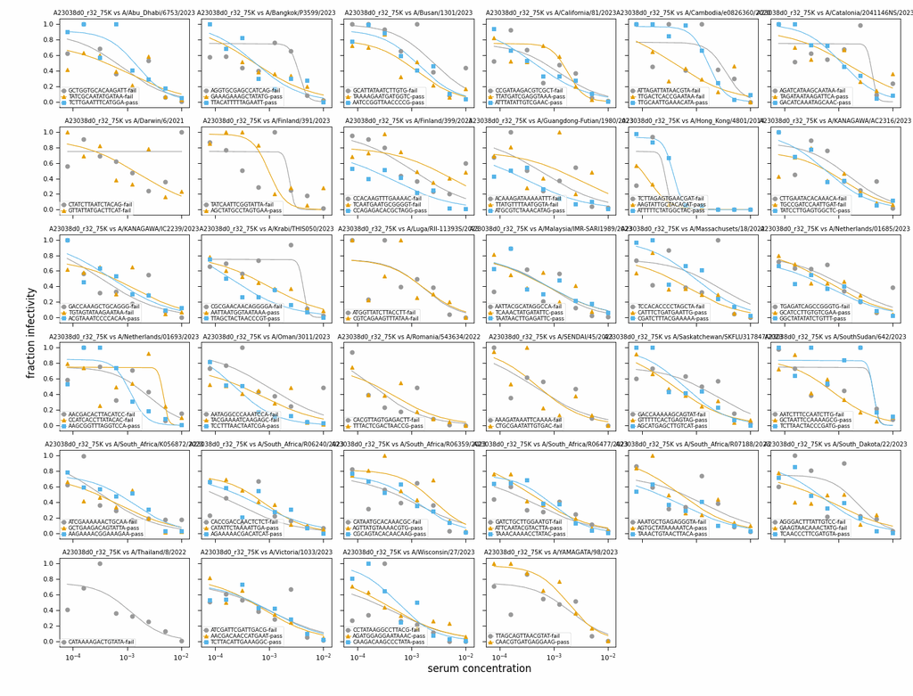

```python
barcode_serum_replicates_fail_qc = fit_params_noqc.query("fails_qc").reset_index(
    drop=True
)
print(f"Here are barcode / serum-replicates that fail {curvefit_qc=}")
display(barcode_serum_replicates_fail_qc)

if len(barcode_serum_replicates_fail_qc):
    print(
        "\nCurves for virus vs serum-replicates with at least one failed barcode."
        "\nColor key labels indicate if barcodes failed or passed QC."
    )
    plots = {}
    ncol = 6
    for iplot, (serum, virus, failed_barcodes) in enumerate(
        barcode_serum_replicates_fail_qc.groupby(
            ["serum_replicate", "virus"], as_index=False
        )
        .aggregate(barcodes=pd.NamedAgg("barcode", list))
        .itertuples(index=False)
    ):
        passed_barcodes = [
            bc
            for bc in fits_noqc.replicates[serum, virus]
            if (bc not in failed_barcodes) and (bc != "average")
        ]
        curvelist = []
        assert len(CBMARKERS) >= len(failed_barcodes + passed_barcodes)
        assert len(CBPALETTE) >= len(failed_barcodes + passed_barcodes)
        for replicate, marker, color in zip(
            failed_barcodes + passed_barcodes, CBMARKERS, CBPALETTE
        ):
            curvelist.append(
                {
                    "serum": serum,
                    "virus": virus,
                    "replicate": replicate,
                    "label": replicate
                    + ("-fail" if replicate in failed_barcodes else "-pass"),
                    "color": color,
                    "marker": marker,
                }
            )
        plots[iplot // ncol, iplot % ncol] = (f"{serum} vs {virus}", curvelist)

    fig, _ = fits_noqc.plotGrid(
        plots,
        attempt_shared_legend=False,
        legendfontsize=8,
        titlesize=9,
        ticksize=10,
        draw_in_bounds=True,
    )
    display_curve_fig(fig, curve_display_method)
    plt.close(fig)
```

```python
# drop barcode / serum-replicates failing QC
for qc_filter in ["max_frac_infectivity_at_least", "goodness_of_fit"]:
    fits_qc_drops = list(
        fit_params_noqc.query(f"fails_{qc_filter} and (not ignore_qc)")[
            ["barcode", "serum_replicate"]
        ].itertuples(index=False, name=None)
    )
    print(
        f"\nDropping {len(fits_qc_drops)} barcode/serum-replicates for failing "
        f"{qc_filter}={curvefit_qc[qc_filter]}: " + str(fits_qc_drops)
    )
    qc_drops["barcode_serum_replicates"].update({w: qc_filter for w in fits_qc_drops})
    frac_infectivity = frac_infectivity[
        ~frac_infectivity.assign(
            barcode_serum_replicate=lambda x: x.apply(
                lambda r: (r["barcode"], r["serum_replicate"]), axis=1
            )
        )["barcode_serum_replicate"].isin(qc_drops["barcode_serum_replicates"])
    ]
    fit_params_noqc = fit_params_noqc[
        ~fit_params_noqc.assign(
            barcode_serum_replicate=lambda x: x.apply(
                lambda r: (r["barcode"], r["serum_replicate"]), axis=1
            )
        )["barcode_serum_replicate"].isin(qc_drops["barcode_serum_replicates"])
    ]
```

```
Dropping 0 barcode/serum-replicates for failing max_frac_infectivity_at_least=0: []

Dropping 46 barcode/serum-replicates for failing goodness_of_fit={'min_R2': 0.7, 'max_RMSD': 0.1}: [('AAAGATAAATTCAAAA', 'A23038d0_r32_75K'), ('AAATGCTGAGAGGGTA', 'A23038d0_r32_75K'), ('AACGACACTTACATCC', 'A23038d0_r32_75K'), ('AATAGGCCCAAATCCA', 'A23038d0_r32_75K'), ('AATCTTTCCAATCTTG', 'A23038d0_r…
```

## Fit neutralization curves after applying QC

No we re-fit curves after applying all the QC:

```python
fits_qc = neutcurve.CurveFits(
    frac_infectivity.rename(
        columns={
            "frac_infectivity_ceiling": "fraction infectivity",
            "concentration": "serum concentration",
        }
    ),
    conc_col="serum concentration",
    fracinf_col="fraction infectivity",
    virus_col="strain",
    serum_col="serum",
    replicate_col="plate_barcode",
    fixtop=curvefit_params["fixtop"],
    fixbottom=curvefit_params["fixbottom"],
    fixslope=curvefit_params["fixslope"],
)

fit_params_qc = fits_qc.fitParams(average_only=False, no_average=True)
assert len(fit_params_qc) <= len(
    fits_noqc.fitParams(average_only=False, no_average=True)
)

print(f"Assigning fits for this plate to {group}")
fit_params_qc.insert(0, "group", group)
```

```
Assigning fits for this plate to pilot
```

Plot all the curves that passed QC:

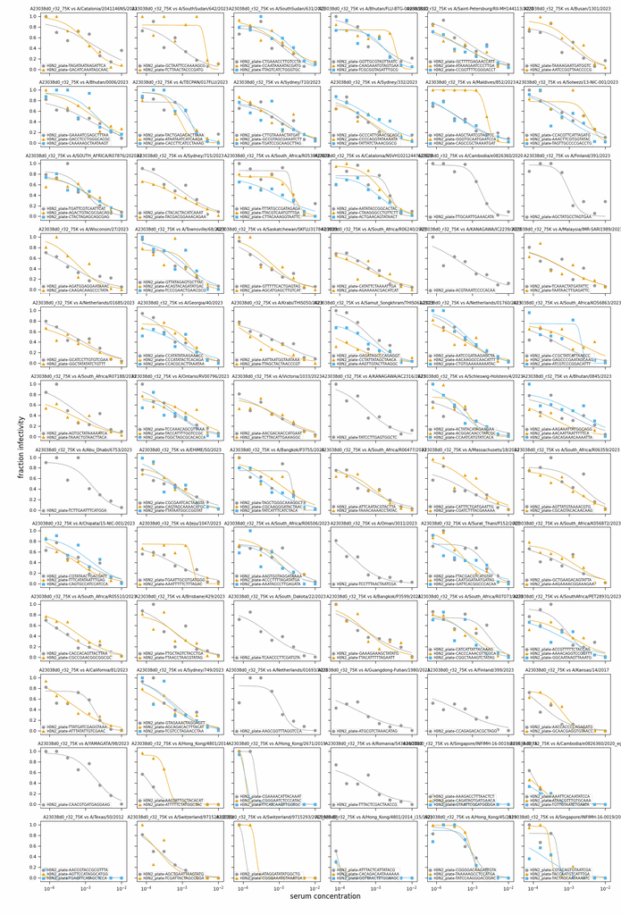

```python
if fits_qc.sera:
    fig, _ = fits_qc.plotReplicates(
        attempt_shared_legend=False,
        legendfontsize=8,
        titlesize=9,
        ticksize=10,
        ncol=6,
        draw_in_bounds=True,
    )
    display_curve_fig(fig, curve_display_method)
    plt.close(fig)
else:
    print("No sera passed QC.")
```

## Save results to files

```python
print(f"Writing fraction infectivities to {frac_infectivity_csv}")
(
    frac_infectivity[
        [
            "serum",
            "strain",
            "plate_barcode",
            "dilution_factor",
            "frac_infectivity_raw",
            "frac_infectivity_ceiling",
        ]
    ]
    .sort_values(["serum", "plate_barcode", "dilution_factor"])
    .to_csv(frac_infectivity_csv, index=False, float_format="%.4g")
)

print(f"\nWriting fit parameters to {fits_csv}")
(
    fit_params_qc.drop(columns=["nreplicates", "ic50_str"]).to_csv(
        fits_csv, index=False, float_format="%.4g"
    )
)

print(f"\nPickling neutcurve.CurveFits object for these data to {fits_pickle}")
with open(fits_pickle, "wb") as f:
    pickle.dump(fits_qc, f)

print(f"\nWriting QC drops to {qc_drops_yaml}")


def tup_to_str(x):
    return " ".join(x) if isinstance(x, tuple) else x


qc_drops_for_yaml = {
    key: {tup_to_str(key2): val2 for key2, val2 in val.items()}
    for key, val in qc_drops.items()
}
with open(qc_drops_yaml, "w") as f:
    yaml.YAML(typ="rt").dump(qc_drops_for_yaml, f)
print("\nHere are the QC drops:\n***************************")
yaml.YAML(typ="rt").dump(qc_drops_for_yaml, sys.stdout)
```

```
Writing fraction infectivities to results/plates/H3N2_plate/frac_infectivity.csv

Writing fit parameters to results/plates/H3N2_plate/curvefits.csv

Pickling neutcurve.CurveFits object for these data to results/plates/H3N2_plate/curvefits.pickle

Writing QC drops to results/plates/H3N2_plate/qc_drops.yml

Here are the QC drops:
wells: {}
barcodes:
  AAAGTAGCAGAGGATT: min_neut_standard_frac_per_well
  AATGACAGCTGTCTAG: min_neut_standard_frac_per_well
  AATGGTCGAGCCATTC: min_neut_standard_frac_per_well
  ACGCAAATAGACCGAA: min_neut_standard_frac_per_well
  AGACCATCGCACCCAA: min_neut_standard_frac_per_well
  ATAGAAAATTATCCGC: min_neut_standard_frac_per_well
  CAAAAGCAGCACGATA: min_neut_standard_frac_per_well
  CAATTCGCCGTTCCCC: min_neut_standard_frac_per_well
  CCAATCCCAGCCTTTA: min_neut_standard_frac_per_well
  CCCGCTAACCCTGTCT: min_neut_standard_frac_per_well
  CCCTCCTCAAGGGTAA: min_neut_standard_frac_per_well
  CCGCAATGACAATTTG: min_neut_standard_frac_per_well
  CGTACGTATGTCCCAG: min_neut_standard_frac_per_well
  CGTCCCTGGCGTGTCG: min_neut_standard_frac_per_well
  CGTTAACGGCCTATCC: min_neut_standard_frac_per_well
  CTCATTACAGAAATTG: min_neut_standard_frac_per_well
  CTCCAATAGGAGACGA: min_neut_standard_frac_per_well
  CTTCATCTCATTTAAA: min_neut_standard_frac_per_well
  TATACTCACGGAGGAT: min_neut_standard_frac_per_well
  TATATGGAATACTAAA: min_neut_standard_frac_per_well
  TCCCCGTGGTTTGACA: min_neut_standard_frac_per_well
  TCCGCCACTATAACAT: min_neut_standard_frac_per_well
  TCTCCGATAGCCCTAC: min_neut_standard_frac_per_well
  TGACAAACACCTGAGG: min_neut_standard_frac_per_well
barcode_wells:
  CCTATAAGGCCTTACG A10: min_no_serum_count_per_viral_barcode_well
  GATTCACGGCCCACAA B10: min_no_serum_count_per_viral_barcode_well
  CACCGACCAACTCTCT E10: min_no_serum_count_per_viral_barcode_well
  GACCAAAGCTGCAGGG E10: min_no_serum_count_per_viral_barcode_well
```

[output cut: 33 more lines]

```
  GCTGGTGCACAAGATT A23038d0_r32_75K: goodness_of_fit
  GTTATTATGACTTCAT A23038d0_r32_75K: goodness_of_fit
  TACGAAAATCAAGAGC A23038d0_r32_75K: goodness_of_fit
  TATCAATTCGGTATTA A23038d0_r32_75K: goodness_of_fit
  TATCGCAATATGATAA A23038d0_r32_75K: goodness_of_fit
  TCAATGAATGCGGGGT A23038d0_r32_75K: goodness_of_fit
  TCCACACCCCTAGCTA A23038d0_r32_75K: goodness_of_fit
  TCTTAGAGTGAACGAT A23038d0_r32_75K: goodness_of_fit
  TGAGATCAGCCGGGTG A23038d0_r32_75K: goodness_of_fit
  TGCCGATCCAATTGAT A23038d0_r32_75K: goodness_of_fit
  TGTAGTATAAGAATAA A23038d0_r32_75K: goodness_of_fit
  TTAGCAGTTAACGTAT A23038d0_r32_75K: goodness_of_fit
  TTATGTTTTAATGGTA A23038d0_r32_75K: goodness_of_fit
  TTGACTCACCGAATAA A23038d0_r32_75K: goodness_of_fit
serum_replicates: {}
```